# Memorial

#### **Memorial Descritivo**

##### **Dados do Imóvel**

Tipo de Imóvel: **RURAL**; Uso: **ALVENARIA**; Proprietário: **Luciana Silva Da Costa** ; CPF: **064.788.292-27**; Endereço: **Aturaxana ipe, casa nº2, Estrada Campos Elíseos, Ramal Brasileirinho, km8, Manaus, Brasil**; Comarca: **Tabelião Zé Carioca**; Área: **120m<sup>2</sup>**; Perímetro: **46m**; Descrição: Projeto, Levantamento Topográfico, Planta e Memorial descritivo

##### **Limites e confrontações do terreno**

| Marcos | Coordenadas |
| --- | --- |
| M01 | 3°0′58.03″S / 59°52′21.00″W |
| M02 | 3°0′58.20″S / 59°52′21.21″W |
| M03 | 3°0′57.78″S / 59°52′21.52″W |
| M04 | 3°0′57.62″S / 59°52′21.32″W |

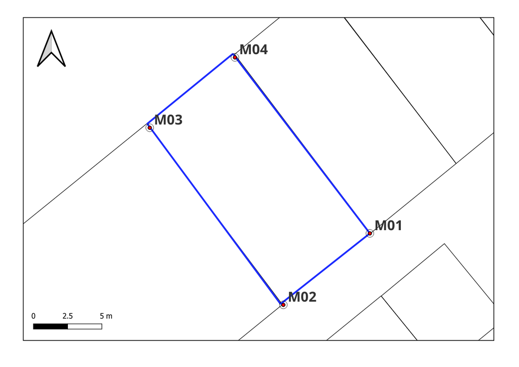

##### **Descrição das faces do terreno**

**Frente (SUL)**: Frente para a Aturaxana ipe, corresponde ao segmento que une os marcos M-01 (3°0′58.03″S / 59°52′21.00″W) e M-02 (3°0′58.20″S / 59°52′21.21″W), com comprimento de 8 metros.

**Lateral direita (OESTE)**: confronta-se com o terreno da casa 1. É constituída pela linha imaginária entre os marcos M-02 (3°0′58.20″S / 59°52′21.21″W) e M-03 (3°0′57.78″S / 59°52′21.52″W), com 15 metros.

**Fundos (NORTE)**: o fundo do terreno é demarcado pelos pontos M-03 (3°0′57.78″S / 59°52′21.52″W) e M-04 (3°0′57.62″S / 59°52′21.32″W), distantes 8 metros entre si.

**Lateral esquerda (LESTE)**: confronta-se com o terreno da casa 4. A linha que une os marcos M-04 (3°0′57.62″S / 59°52′21.32″W) e M-01 (3°0′58.03″S / 59°52′21.00″W), distantes (15 metros).

*Observações*:

Manaus 03, de março de 2023.

| Responsável técnico: Fulana Ciclana – Geógrafa (CREAM-AM 123456789-0) |  | Proprietário(a): Luciana Silva Da Costa |
| --- | --- | --- |